# Day 7 - Creating reports and documenting dependencies

Lucas A. Nell and Maggie L. Warren

2023-12-04

## Documenting dependencies

- Critical for others to be able to reproduce your results
- R itself is pretty stable, but many packages are not especially years (and many version) later
- We’ll describe three increasingly complex (and more complete) ways of allowing others to access your exact dependencies:
1. List packages
2. Create a package library for your project
3. Use a container

## 1. List packages

## 2. Create a package library for your project

### Package `renv`

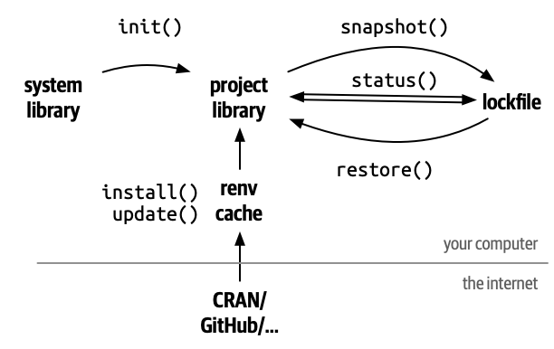

To get started (it automatically discovered loaded packages):

```r
renv::init()
```

To save metadata on all packages and versions:

```r
renv::snapshot()
```

To reproduce environment that you’ve saved:

```r
renv::restore()
```

## 3. Use a container

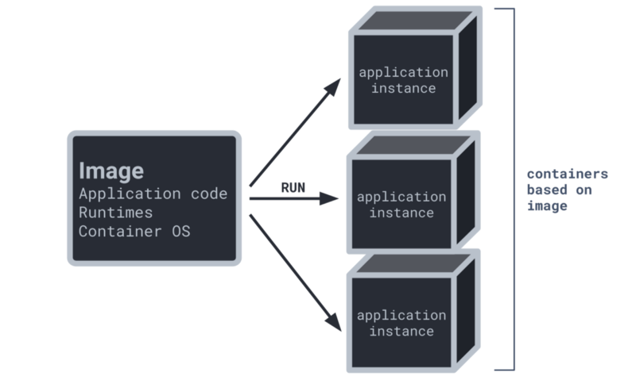

- Docker and Singularity are popular options
- Reproduce your entire operating system, including all installed software
- Can be useful for software that is difficult to install or in environments that limit your ability to install software, like computer clusters

## 3. Use a container (cont.)

You can use an existing image. Many programs create them for users, check out https://hub.docker.com

Or make your own. Example: https://shorturl.at/pGT25

```bash
# start with a bare-bones ubuntu with mamba installed:
FROM condaforge/mambaforge:4.11.0-0

# install some basics:
RUN apt-get clean && \
    apt-get update -y && \
    apt-get install -y build-essential && \
    apt-get install -y locales wget rsync unzip nano sudo pv cmake \
        ocaml-nox zlib1g-dev libbz2-dev liblzma-dev libboost-all-dev \
        libcurl4-openssl-dev

# add a conda environment with a bunch of packages:
COPY env-main.yml .
RUN mamba env create -q -f env-main.yml && \
    rm env-main.yml && \
    conda clean --all -y

# and so on, as much as you need
```

## What method seems most appealing for your projects?

## Reports - What and why?

- A mix of text, tables, figures, equations, etc. — alongside the code that created them.
- Can be used to share results to a few collaborators or as a final manuscript document (although smaller documents are more typical).
- By having code next to results, your analyses are easier to validate

We’re focusing on notebooks using RMarkdown, but Jupyter notebooks in python are also great.

## R Markdown

- Markdownhttps://www.markdownguide.org/basic-syntax/ plus R (or other) code
- The code can be actually run with the output shown in the final document
- File extension is `.Rmd`, and output can be many options
- See cheatsheet on Canvas or here: https://rstudio.github.io/cheatsheets/rmarkdown.pdf

[figure not shown]

https://www.britishecologicalsociety.org/publications/better-science/

## YAML header

```
--
title: "My report"
author: "Your Name"
date: "Today"
output: pdf_document
---
```

Controls the output formatting and basic info about your report

## Code chunks

### Can be both blocks and inline!

````
```{r chunk-name}
set.seed(1)
x <- rnorm(100)
```
The mean is `r mean(x)`
````

The mean is 0.1088874

## Setup code chunk

Added by default when creating a new Rmd file in RStudio

````
```{r setup, include=FALSE}
knitr::opts_chunk$set(echo = TRUE)
```
````

Sets default options for code chunks, including…https://bookdown.org/yihui/rmarkdown/r-code.html

- `eval`: Whether to evaluate a code chunk.
- `echo`: Whether to echo the source code in the output document.
- `warning`, `message`, and `error`: Whether to show warnings, messages, and errors in the output document.
- `include`: Whether to include anything from a code chunk in the output document.
- `fig.width` and `fig.height`: The (graphical device) size of R plots in inches.

More listed at https://yihui.name/knitr/options

## Figures

````
This is a cool plot I made:
```{r chunk-name}
plot(x, type = "l")
```
````

This is a cool plot I made:

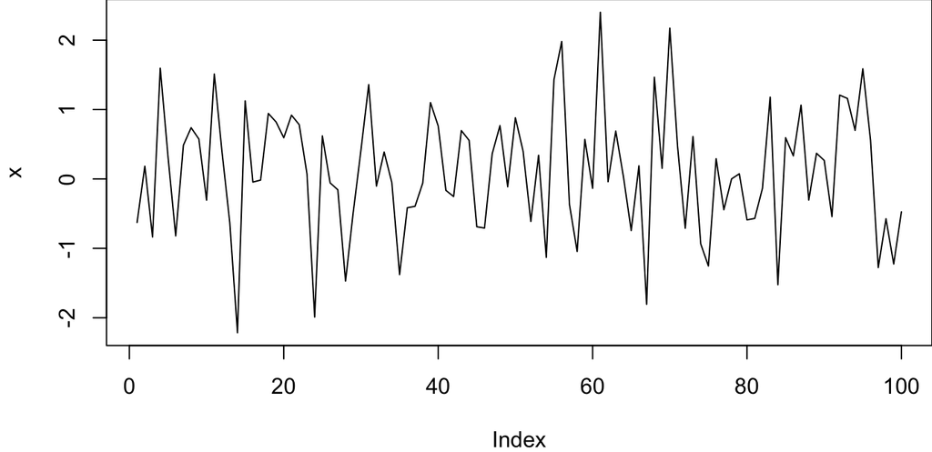

## Tables

````
```{r iris-table}
iris |>
  group_by(Species) |>
  summarize(sepal_length = mean(Sepal.Length),
            sepal_width = mean(Sepal.Width)) |>
  knitr::kable(caption = "Mean sepal width and length for three species of _Iris_.")

```
````

Mean sepal width and length for three species of *Iris*.

| Species | sepal_length | sepal_width |
| --- | --- | --- |
| setosa | 5.006 | 3.428 |
| versicolor | 5.936 | 2.770 |
| virginica | 6.588 | 2.974 |

## Cross-referencing and citations

### Cross-referencing

```
As you can see in table \@ref(iris-table)...
```

### Citations

Add to your YAML header:

```
bibliography: references.bib
csl: refstyle.csl
```

- `references.bib` is a BibTeX file with all your references
- `refstyle.csl` is a file specifying the citation style (see https://www.zotero.org/styles).

## Let’s create reports for your projects

1. File > New File > R Markdown…
2. Insert name and title, select PDF, hit OK

Work on your own for a bit: Don’t try to include everything now; just outline what you want to include

Then pair up and discuss, see if there are ways to improve each other’s documents

## More information

*R Markdown: The Definitive Guide* https://bookdown.org/yihui/rmarkdown/

*Report writing for data science in R* http://leanpub.com/reportwriting

`bookdown`*: Authoring Books and Technical Documents with R Markdown* https://bookdown.org/yihui/bookdown/

*A Guide to Reproducible Code in Ecology and Evolution* https://www.britishecologicalsociety.org/publications/better-science/

https://rmarkdown.rstudio.com/